# K-means clustering & Schools.csv

# Clustering analysis using AgglomerativeClustering (# of clusters = 2)

```python
#agglomerative clustering model
np.random.seed(1) # setting random seed to get the same results each time.

agg= AgglomerativeClustering(n_clusters=2, linkage='ward').fit(X)
agg.labels_
```

```
array([0, 0, 0, ..., 1, 0, 1])
```

```python
#To add cluster label into the dataset as a column
ac_c = pd.DataFrame(agg.labels_, columns = ['cluster'])
ac_c.head()
```

|  | cluster |
| --- | --- |
| 0 | 0 |
| 1 | 0 |
| 2 | 0 |
| 3 | 0 |
| 4 | 0 |

```python
# join original data & cluster data
ac_c = ac_c.reset_index(drop=True)

ac = df_new.join(ac_c)
ac.head()
```

|  | Pct_First_Language_Not_English | Pct_English_Language_Learner | Pct_Students_With_Disabilities | Pct_High_Needs | Pct_Economically_Disadvantaged | Pct_African_American | Pct_Asian | Pct_Hispanic | Pct_White | Pct_Native_American | Pct_Native_Hawaiian_Pacific_Isla | Pct_MultiRace_NonHispanic | Pct_Males | Pct_Females | Average_Class_Size | cluster |
| --- | --- | --- | --- | --- | --- | --- | --- | --- | --- | --- | --- | --- | --- | --- | --- | --- |
| 0 | 5.3 | 2.4 | 9.7 | 28.8 | 21.5 | 2.2 | 1.5 | 9.1 | 85.8 | 0.2 | 0.2 | 0.9 | 45.6 | 54.4 | 15.8 | 0 |
| 1 | 10.5 | 7.2 | 13.3 | 37.1 | 23.3 | 1.9 | 1.9 | 6.7 | 88.4 | 0.5 | 0.2 | 0.3 | 50.2 | 49.8 | 24.6 | 0 |
| 2 | 12.8 | 3.0 | 21.2 | 34.0 | 16.3 | 3.9 | 3.0 | 8.4 | 84.7 | 0.0 | 0.0 | 0.0 | 54.2 | 45.8 | 14.6 | 0 |
| 3 | 5.5 | 1.8 | 13.1 | 30.8 | 21.6 | 2.4 | 1.8 | 6.1 | 89.3 | 0.0 | 0.0 | 0.3 | 53.4 | 46.6 | 21.1 | 0 |
| 4 | 5.9 | 2.0 | 10.8 | 30.6 | 22.7 | 2.0 | 1.4 | 4.2 | 92.1 | 0.0 | 0.0 | 0.3 | 50.7 | 49.3 | 30.4 | 0 |

```python
#get average values for each variable by cluster
ac.groupby('cluster').mean()
```

| cluster | Pct_First_Language_Not_English | Pct_English_Language_Learner | Pct_Students_With_Disabilities | Pct_High_Needs | Pct_Economically_Disadvantaged | Pct_African_American | Pct_Asian | Pct_Hispanic | Pct_White | Pct_Native_American | Pct_Native_Hawaiian_Pacific_Isla | Pct_MultiRace_NonHispanic | Pct_Males | Pct_Females | Average_Class_Size |
| --- | --- | --- | --- | --- | --- | --- | --- | --- | --- | --- | --- | --- | --- | --- | --- |
| 0 | 8.950077 | 3.638717 | 16.777512 | 34.508346 | 20.413060 | 3.673416 | 5.986167 | 7.297913 | 78.954560 | 0.238253 | 0.094204 | 3.756801 | 51.472798 | 48.520093 | 18.316692 |
| 1 | 42.122306 | 24.050095 | 21.539130 | 75.873157 | 59.521739 | 20.825142 | 6.242344 | 47.601134 | 21.784877 | 0.213800 | 0.103592 | 3.230813 | 52.958979 | 47.039130 | 18.330057 |

```python
#get number of observations by cluster
ac.groupby('cluster').size()
```

```
cluster
0    1294
1     529
dtype: int64
```

## Visualize dendrogram

- p = 2

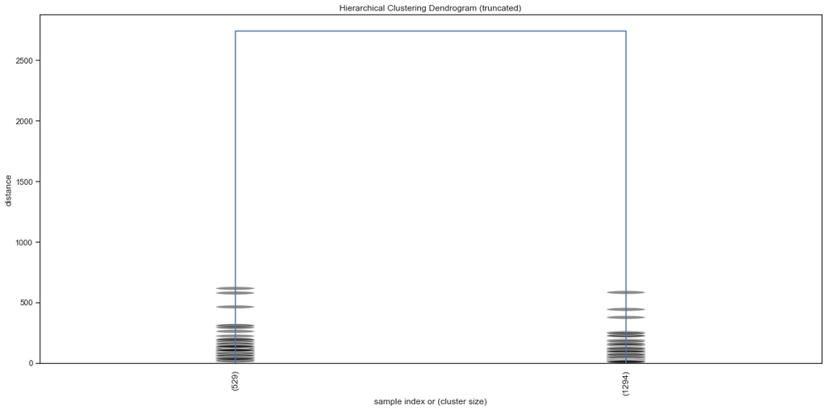

```python
#dendrogram for only two clusters
plt.figure(figsize=(16,8))

plt.title('Hierarchical Clustering Dendrogram (truncated)')
plt.xlabel('sample index or (cluster size)')
plt.ylabel('distance')

linkage_matrix = ward(X)
dendrogram(linkage_matrix,
           truncate_mode='lastp',  # show only the last p merged clusters
           p=2,  # show only the last p merged clusters
           #show_leaf_counts=False,  # otherwise numbers in brackets are counts
           leaf_rotation=90.,
           leaf_font_size=12.,
           show_contracted=True,  # to get a distribution impression in truncated branches
           orientation="top")
plt.tight_layout() # fixes margins
```

## How many observations are in each cluster?

As you can see from the dendrogram and cluster analysis above,

- Cluster 1 has 1294 observations.
- Cluster 2 has 529 observations.

## What is the profile of each cluster?

**Cluster 1:**

- Pct_High_Needs: This cluster has a lower percentage of high needs students with an average of 34.51%.
- Pct_First_Language_Not_English: This cluster has a lower percentage of students whose first language isn't English with an average of 8.95%.
- Pct_English_Language_Learner: This cluster has a lower percentage of students who are learning English with an average of 3.64%.
- Pct_Students_With_Disabilities: This cluster has a lower percentage of students with disabilities with an average of 16.78%.
- Pct_Economically_Disadvantaged: This cluster has a lower percentage of students who are economically disadvantaged with an average of 20.41%.
- Pct_African_American: This cluster has a lower percentage of African-American students with an average of 3.67%.
- Pct_Asian: This cluster has a lower percentage of Asian students with an average of 5.99%.
- Pct_Hispanic: This cluster has a lower percentage of Hispanic students with an average of 7.29%.
- Pct_White: This cluster has a higher percentage of White students with an average of 78.95%.
- Pct_Native_American: This cluster has a low percentage of Native American students with an average of 0.24%.
- Pct_Native_Hawaiian_Pacific_Isla: This cluster has a low percentage of Native Hawaiian and Pacific Islander students with an average of 0.09%.
- Pct_MultiRace_NonHispanic: This cluster has a low percentage of Multi-race and Non-Hispanic students with an average of 3.76%.
- Pct_Males: This cluster has a slightly higher percentage of males than females with and average of 51.47%.
- Pct_Females: This cluster has a slightly lower percentage of females than males with and average of 48.52%.
- Average_Class_Size: This cluster has an average class size of 18.31 students, which is very slightly lower than that of cluster 2.

Based on these findings, this cluster 1 could be described as having less diversity than that of cluster 2. This cluster also has less students with disabilities, economic disadvantages, and another language than English as their first language. There was little difference in class size and male to female ratios between the two clusters. Cluster 1 could be described as having less diversity than Cluster 2. This cluster has less students with disabilities, economic disadvantages, and another language than English as their first language. There was little difference in class size and male to female ratios between the two clusters.

**Cluster 2:**

- Pct_High_Needs: This cluster has a higher percentage of high needs students with an average of 75.87%.
- Pct_First_Language_Not_English: This cluster has a higher percentage of students whose first language isn't English with an average of 42.12%.
- Pct_English_Language_Learner: This cluster has a higher percentage of students who are learning English with an average of 24.05%.
- Pct_Students_With_Disabilities: This cluster has a higher percentage of students with disabilities with an average of 21.54%.
- Pct_Economically_Disadvantaged: This cluster has a higher percentage of students who are economically disadvantaged with an average of 59.52%.
- Pct_African_American: This cluster has a higher percentage of African-American students with an average of 20.83%.
- Pct_Asian: This cluster has a higher percentage of Asian students with an average of 6.24%.
- Pct_Hispanic: This cluster has a higher percentage of Hispanic students with an average of 47.60%.
- Pct_White: This cluster has a lower percentage of White students with an average of 21.78%.
- Pct_Native_American: This cluster has a low percentage of Native American students with an average of 0.21%.
- Pct_Native_Hawaiian_Pacific_Isla: This cluster has a low percentage of Native Hawaiian and Pacific Islander students with an average of 0.10%.
- Pct_MultiRace_NonHispanic: This cluster has a low percentage of Multi-race and Non-Hispanic students with an average of 3.23%.
- Pct_Males: This cluster has a slightly higher percentage of males than females with and average of 52.96%.
- Pct_Females: This cluster has a slightly lower percentage of females than males with and average of 47.04%.
- Average_Class_Size: This cluster has an average class size of 18.33 students, which is very slightly higher than that of cluster 1.

Based on these findings, this cluster 2 could be described as having more diversity than that of cluster 1. This cluster also has more students with disabilities, economic disadvantages, and another language than English as their first language. There was little difference in class size and male to female ratios between the two clusters.

Cluster 2 has more diversity than Cluster 1. This cluster also has more students with disabilities, economic disadvantages, and another language than English as their first language. There was little difference in class size and male to female ratios between the two clusters.

## Compare the results from K-Mean clustering analysis and Agglomerative clustering analysis.

From the K-Means clustering analysis, there were 1295 observations for Cluster 1 and 528 observations for Cluster 2. In the Agglomerative clustering analysis, Cluster 1 had 1294 observations, while Cluster 2 had 529 observations. These analyses performed incredibly similarly, and only varied by the cultering of one observation. Since there was a difference in cluster make-up in each type, there was very small variation in the average percentages and values for each variable, usually no more than a 1% difference. Either of these models would be a good way to cluster the data in this data set, especially since their respective cluster profiles were the same.

Note: Several questions have been adapted from "SAS Enterprise Miner Exercise and Assignment Workbook by Varol Onur Kayhan"